# 精品案例|基于“四大”期刊的作者合作网络社区发现

狗熊会

任务介绍：随着统计学的快速发展，研究统计学科的发展趋势是十分重要工作。本案例研究统计学家们的合作网络，可以探索统计学家之间的合作模式及研究热点。对了解和掌握统计学的发展现状和核心研究群体具有重要的意义。详见本案例推文：[基于“四大”期刊的作者合作网络社区发现](https://mp.weixin.qq.com/s/cq8DJTcdFxaOnnrX9cUymg)。

数据来源与说明：本案例所用数据是利用从[Web of Science](http://apps.webofknowledge.com/)上收集统计学“四大”期刊从2001年至2018年发表的论文的相关信息，构建的作者合作网络。统计学“四大”指的是统计学领域学者公认的四个顶级期刊，其中包括《Annals of Statistics》(AoS)，《Biometrika》，《Journal of American Statistical Association》(JASA)以及《Journal of Royal Statistical Society (Series B)》(JRSS-B)。

这个案例的学习目标包括：

1. 学习**读入和处理**网络结构数据；
2. 学会对网络结构数据进行**描述性分析**；
3. 学会利用**经典网络社区发现算法**探究合作者网络的社区结构；
4. 学会利用R语言进行**网络可视化**。

### 准备工作

```r
#清除工作环境
cat("\014");rm(list=ls())
```

```r
#加载相应的包
library(igraph)
library(dplyr)
library(ggplot2)
```

### 任务一: 读入数据并构建网络

找到边数据文件`edge_core.csv`并读入。利用igraph包中的`graph_from_data_frame()`函数构造无向有权的合作者网络。并计算该网络的节点数、边数和网络密度。

```
## [1] "网络的节点数为：1061"
```

```
## [1] "网络的边数为：3310"
```

```
## [1] "网络的密度为：0.00588622339195846"
```

### 任务二: 度分布直方图

使用`degree()`函数计算节点的度，绘制度分布直方图，并进行简要解读。

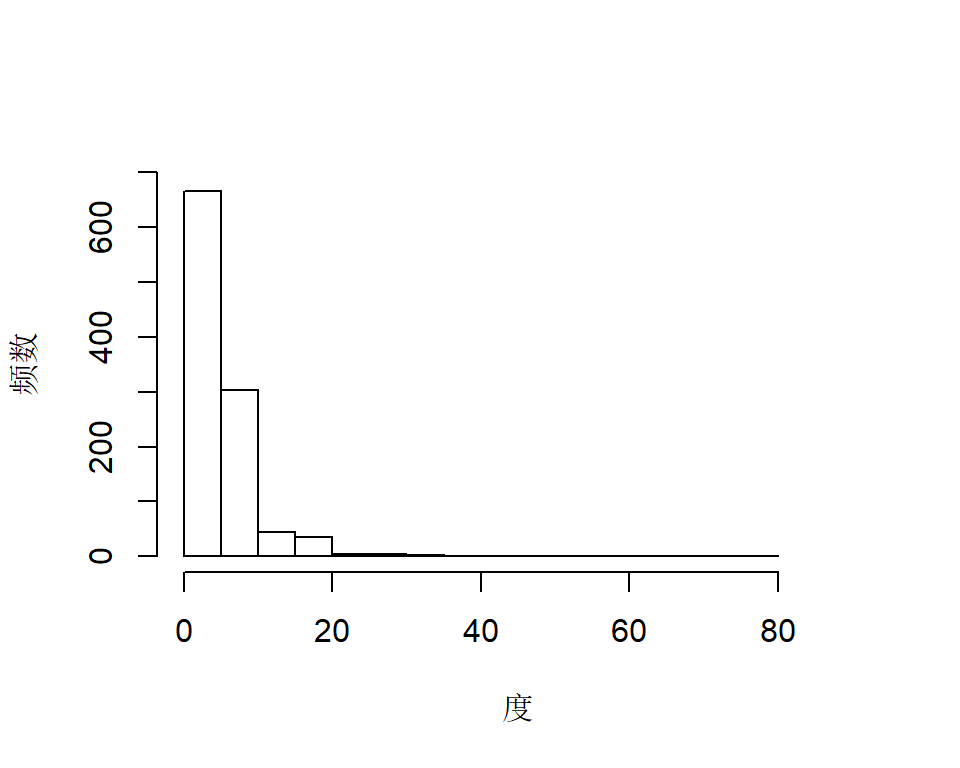

### 任务三：节点度

使用`degree()`函数计算节点的度，并保存为数据框。节点的唯一标识是行名，将行名新增为一列，命名为`name`。按照节点度由大到小排序，并读入作者信息`author.csv`文件，利用`name`字段匹配作者姓名和单位，展示排名前10的作者。并进行简要解读。

```
##    deg       name           author
## 1   76    A7232-0       Carroll, R
## 2   42   A21046-0       Ibrahim, J
## 3   40   A52163-1          Zeng, D
## 4   33   A13633-1    Fan, Jianqing
## 5   31 A52370-0-2      Zhu, Hongtu
## 6   29   A28821-0 Mallick, Bani K.
## 7   27   A18422-0          Hall, P
## 8   27   A27464-1      Liu, Yufeng
## 9   26   A50962-2       Wu, Yichao
## 10  23    A6744-1     Cai, T. Tony
```

### 任务四：中介中心性

使用`betweenness()`函数计算节点的中介中心性，注意设置参数为`normalized = T`，并保存为数据框。节点的唯一标识是行名，将行名新增为一列，命名为`name`。按照节点度由大到小排序，展示排名前10的作者。并进行简要解读。

```
##           bet       name            author
## 1  0.20961766    A7232-0        Carroll, R
## 2  0.08831861 A27238-0-4            Lin, X
## 3  0.08409533   A18422-0           Hall, P
## 4  0.06157773    A6744-1      Cai, T. Tony
## 5  0.06057539   A12402-0     Dunson, D. B.
## 6  0.05931473 A52370-0-2       Zhu, Hongtu
## 7  0.05834324   A21046-0        Ibrahim, J
## 8  0.05425690   A13633-1     Fan, Jianqing
## 9  0.05173651   A36602-0 Pillai, Natesh S.
## 10 0.04876852   A52163-1           Zeng, D
```

### 任务五：网络社区发现

使用`multilevel.community()`函数对网络进行社区发现，展示每个社区的大小并进行简要解读。

```
##
##   1   2   3   4   5   6   7   8   9  10  11  12  13  14  15  16  17  18  19  20
##   6   7   7   5   6   7   6  12   6   5   5  25   5   5   6   6   5  18  37  29
##  21  22  23  24  25  26  27  28  29  30  31  32  33  34  35  36  37  38  39  40
##   5  11  22   5  18  29  33  40   5  32  27  21  32  90  10  13  68   6 107  38
##  41  42  43  44  45  46  47  48
##  17  14  35  50  42  13  15  55
```

### 任务六：网络可视化

```
## [1] "子网络的密度为：0.0523717157467819"
```

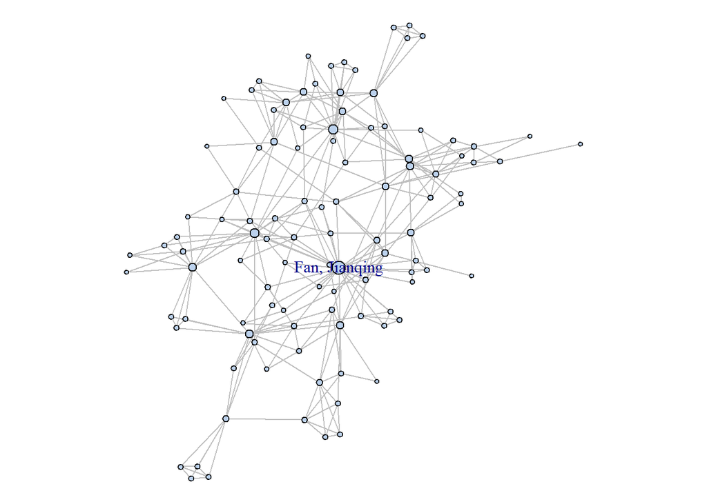